# Mini-Project 03

Visualizing and Maintaining the Green Canopy of NYC

Author

Caitlin Uang

Published

November 16, 2025

## Summary

Despite being a densely metropolitan area, New York City is known for its green spaces for its 8.5 million residents to relax and enjoy nature without having to leave the city.

This project analyzes two datasets from NYC Council District Boundaries and NYC Record of Forestry Tree Points to create compelling visualizations to propose a new program for the NYC Parks and Recreation Department to dedicate funding towards a tree project in my chosen district.

## Data Acquisition

### NYC City Council Districts

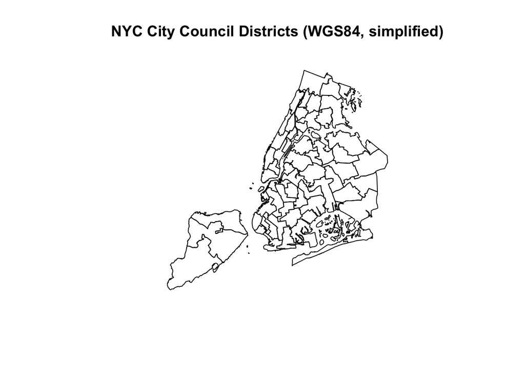

```r
library(sf)
library(tidyverse)
library(httr2)

download_district_boundaries <- function() {

  # Define file paths
  zip_url <- "https://s-media.nyc.gov/agencies/dcp/assets/files/zip/data-tools/bytes/city-council/nycc_25c.zip"
  zip_file <- file.path("data", "mp03", "nycc_25c.zip")
  unzip_dir <- file.path("data", "mp03", "nycc_25c")

  # Create mp03 directory if it doesn't exist
  if(!dir.exists(file.path("data", "mp03"))){
    dir.create(file.path("data", "mp03"), showWarnings=FALSE, recursive=TRUE)
    }

  # Download ZIP file only if needed
  if(!file.exists(zip_file)) {
    download.file(zip_url, destfile = zip_file)
    message("Dowloaded file:", zip_file)
  } else {
      message("ZIP file exists. Skipping download.")
  }

  # Unzip file only if needed
  if (length(list.files(unzip_dir, pattern = "\\.shp$", recursive = TRUE)) == 0) {
    unzip(zip_file, exdir = unzip_dir)
    message("Unzipped files to: ", unzip_dir)
  } else {
    message("ZIP files already unzipped.")
  }

  # Read shapefile
  shp_files <- list.files(unzip_dir, pattern = "\\.shp$", full.names = TRUE, recursive = TRUE)
  if (length(shp_files) == 0) stop("No shapefile found after unzipping.")

  nycc_25c <- sf::st_read(shp_files[1], quiet = TRUE)

  # Transform to WGS84
  nycc_wgs84 <- st_transform(nycc_25c, crs = "WGS84")

  message("Successfully read and transformed shapefile to WGS84.")

  # Return sf to user
  return(nycc_wgs84)
}

boundaries <- download_district_boundaries()

# Optional simplifying
boundaries_simple <- boundaries |>
  st_transform(6539) |>
  mutate(geometry = st_simplify(geometry, dTolerance = 5)) |>
  st_transform("WGS84")

plot(st_geometry(boundaries_simple), main = "NYC City Council Districts (WGS84, simplified)")
```

### NYC Tree Points

```r
library(httr2)
library(sf)
library(dplyr)

download_tree_points <- function(
  base_url = "https://data.cityofnewyork.us/resource/hn5i-inap.geojson",
  out_dir = "data/mp03",
  limit = 50000
) {

  # Create mp03 directory if it doesn't exist
  if (!dir.exists(out_dir)) {
    dir.create(out_dir, showWarnings = FALSE, recursive = TRUE)
  }

  offset <- 0
  page <- 1
  downloaded_files <- c()

  repeat {
    # Construct filename
    file_path <- paste0(out_dir, "/treepoints_", page, ".geojson")

    # Skip if file already exists
    if (file.exists(file_path)) {
      message(paste("✔ File exists:", file_path, "— skipping"))
    } else {
      message(paste("⬇ Downloading page", page, "(offset =", offset, ")"))

      req <- request(base_url) |>
        req_url_query(`$limit` = limit, `$offset` = offset)

      resp <- req_perform(req)
      writeBin(resp_body_raw(resp), file_path)
    }

    downloaded_files <- c(downloaded_files, file_path)

    # Check number of rows returned
    temp_data <- suppressWarnings(st_read(file_path, quiet = TRUE))
    n_returned <- nrow(temp_data)

    message(paste("   → Rows returned:", n_returned))

    if (n_returned < limit) {
      message("✔ Final page reached — stopping.")
      break
    }

    offset <- offset + limit
    page <- page + 1
  }

  message("Combining files...")

  all_data <- lapply(downloaded_files, \(f) st_read(f, quiet = TRUE)) |>
    bind_rows()

  message(paste("Download complete. Total rows:", nrow(all_data)))

  return(all_data)
}

# Run the function
tree_points <- download_tree_points()
```

## Data Integration and Initial Explortion

### Mapping NYC Trees

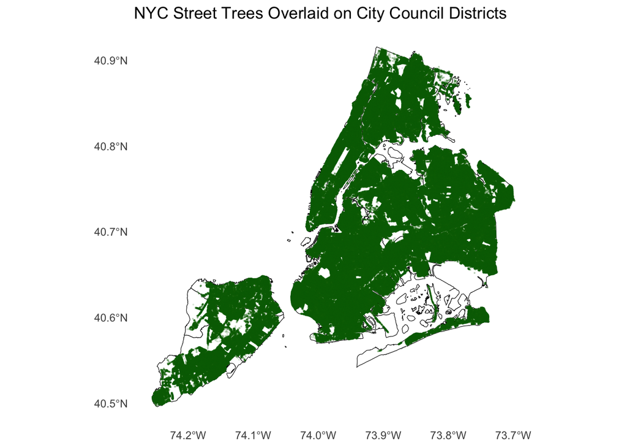

```r
library(ggplot2)

ggplot() +
  # Plot Council district boundaries (polygons)
  geom_sf(
    data = boundaries_simple,
    fill = "white",
    color = "black",
    linewidth = 0.2
  ) +

  # Plot Tree point locations
  geom_sf(
    data = tree_points,
    color = "darkgreen",
    alpha = 0.1,
    size = 0.1
  ) +

  labs(
    title = "NYC Street Trees Overlaid on City Council Districts"
  ) +

  theme_minimal() +
  theme(
    panel.grid.major = element_blank(),
    panel.grid.minor = element_blank()
  )
```

### District-Level Analyses of Trees

```r
# Joining tree point onto district boundaries (simplified)
joined_trees <- st_join(
  tree_points,
  boundaries_simple,
  join = st_intersects
)
```

#### 1. Which council district has the most tree?

```r
library(DT)

most_trees <- joined_trees |>
  st_drop_geometry() |>
  count(CounDist, name = "Tree Count") |>
  rename(`Council District` = CounDist) |>
  slice_max(`Tree Count`, n = 1) |>
  select(`Council District`, `Tree Count`)

datatable(
  most_trees,
  rownames = FALSE,
  caption = "Council District with the Most Trees",
  options = list(
  dom = 't')
)|>
formatRound(
    columns = "Tree Count",
    digits = 0,
    mark = ","
  )
```

| Council District | Tree Count |
| --- | --- |
| 51 | 70965 |

The district with the most trees is District 51 in Staten Island at 70,965 trees.

#### 2. Which council district has the highest density of trees?

```r
# Calculate tree density and show only the densest district
densest_trees <- joined_trees |>
  st_drop_geometry() |>
  count(CounDist, Shape_Area, name = "Tree_Count") |>
  mutate(
    area_km2 = Shape_Area / 1e6,
    density  = Tree_Count / area_km2
  ) |>
  slice_max(density, n = 1) |>
  # Clean column names
  mutate(
    `Council District` = CounDist,
    `Tree Count` = Tree_Count,
    `Area (km2)` = round(area_km2, 2),
    `Tree Density` = round(density, 2)
  ) |>
  # Select ONLY the formatted columns
  select(`Council District`, `Tree Count`, `Area (km2)`, `Tree Density`)

# Show densest district via datatable
datatable(
  densest_trees,
  rownames = FALSE,
  caption = "Council District with the Highest Density of Trees",
  options = list(dom = 't')
) |>
  formatRound(
    columns = "Tree Count",
    digits = 0,
    mark = ","
  )
```

| Council District | Tree Count | Area (km2) | Tree Density |
| --- | --- | --- | --- |
| 7 | 15651 | 55.19 | 283.6 |

The district with the highest density of trees is District 7 in Manhattan at 283.6 trees per km2.

#### 3. Which district has the highest fraction of dead trees out of all trees?

```r
dead_fraction <- joined_trees |>
  st_drop_geometry() |>
  mutate(dead_trees = tpcondition == "Dead") |>
  group_by(CounDist) |>
  summarise(
    total_trees = n(),
    dead_trees = sum(dead_trees, na.rm = TRUE),
    fraction_dead = dead_trees / total_trees
  ) |>
  slice_max(fraction_dead, n = 1) |>
  mutate(
    `Council District` = CounDist,
    `Total Trees` = total_trees,
    `Dead Trees` = dead_trees,
    `Fraction of Dead Trees` = fraction_dead
  ) |>
  select(`Council District`, `Total Trees`, `Dead Trees`, `Fraction of Dead Trees`)

datatable(
  dead_fraction,
  rownames = FALSE,
  caption = "Council District with the Highest Fraction of Dead Trees",
  options = list(dom = 't')
) |>
  formatRound(c("Total Trees", "Dead Trees"), 0, mark = ",") |>
  formatRound("Fraction of Dead Trees", 2)
```

| Council District | Total Trees | Dead Trees | Fraction of Dead Trees |
| --- | --- | --- | --- |
| 32 | 30273 | 4315 | 0.1425362534271463 |

#### 4. What is the most common tree species in Manhattan?

```r
# Create a new column for Borough using case_when()
joined_trees_borough <- joined_trees |>
  mutate(
    Borough = case_when(
      CounDist >= 1  & CounDist <= 10 ~ "Manhattan",
      CounDist >= 11 & CounDist <= 18 ~ "Bronx",
      CounDist >= 19 & CounDist <= 32 ~ "Queens",
      CounDist >= 33 & CounDist <= 48 ~ "Brooklyn",
      CounDist >= 49 & CounDist <= 51 ~ "Staten Island"
    )
  )

# Filter to show only Manhattan and find most common species
manhattan_trees <- joined_trees_borough |>
  st_drop_geometry() |>
  filter(Borough == "Manhattan") |>
  count(genusspecies, name = "Count") |>
  slice_max(Count, n = 1) |>
  mutate(
    `Tree Species` = genusspecies,
    `Total Count of Tree Species` = Count
  ) |>
  select(`Tree Species`,`Total Count of Tree Species`)

datatable(
  manhattan_trees,
  rownames = FALSE,
  caption = "Most Common Tree Species in Manhattan",
  options = list(dom = 't')
) |>
  formatRound("Total Count of Tree Species", 0, mark = ",")
```

| Tree Species | Total Count of Tree Species |
| --- | --- |
| Gleditsia triacanthos var. inermis - Thornless honeylocust | 17310 |

The most common tree species in Manhattan is the Gleditsia triacanthos var. inermis - Thornless honeylocust with a total count of 17,310 trees in the borough.

#### 5. What is the species of the tree closest to Baruch’s campus?

The coordinates of Baruch College is latitude = 40.740278 N and longitude = -73.983333 W.

```r
# Function to create an sf point from lat/lon (WGS84)
new_st_point <- function(lat, lon, ...){
  st_sfc(st_point(c(lon, lat))) |>
    st_set_crs("WGS84")
}

# 2. Baruch College coordinates
baruch_point <- new_st_point(40.740278, -73.983333)

# 3. Transform BOTH Baruch + Tree dataset to feet
baruch_point_feet <- baruch_point |>
  st_transform(2263)

joined_trees_feet <- joined_trees |>
  st_transform(2263)

# Compute distance from each tree to Baruch
distance_trees <- joined_trees_feet |>
  mutate(distance_ft = as.numeric(st_distance(geometry, baruch_point_feet)))

# Find the closest tree
closest_tree <- distance_trees |>
  st_drop_geometry() |>
  select(genusspecies, distance_ft) |>
  slice_min(distance_ft, n = 1) |>
  mutate(
    `Tree Species` = genusspecies,
    `Distance From Baruch (ft)` = distance_ft
  ) |>
  select(`Tree Species`, `Distance From Baruch (ft)`)

# Datatable
datatable(
  closest_tree,
  rownames = FALSE,
  caption = "Closest Tree Species to Baruch College",
  options = list(dom = 't')
) |>
  formatRound("Distance From Baruch (ft)", 2)
```

| Tree Species | Distance From Baruch (ft) |
| --- | --- |
| Liquidambar styraciflua - sweetgum | 75.53687022352838 |

The closest tree species to Baruch College is the Liquidambar styraciflua - sweetgum with a distance of 75.54 feet away from campus.

### Improved Tree Map Visualizations